# Analisis Data Penyewaan Film pada Database Sakila sebagai Dasar Pengambilan Keputusan Manajerial

Laia Rafa Sulistyadi | NIM: M0724062 | Kelas: B

26 May 2026

# 1 Pendahuluan

## 1.1 Latar Belakang

Keberhasilan operasional pada bisnis rental film tidak hanya bergantung pada koleksi film yang tersedia, tetapi juga pada kemampuan manajemen dalam membaca dan merespons pola perilaku pelanggan secara berbasis data. Tanpa analisis yang sistematis, data transaksi hanya menjadi catatan pasif tanpa nilai strategis.

Database **Sakila** merupakan sampel basis data relasional yang merepresentasikan ekosistem toko rental film secara lengkap, mencakup data pelanggan, film, inventaris, hingga rekaman pembayaran. Struktur relasionalnya yang kaya menjadikan Sakila sebagai medium yang ideal untuk mengekstrak *business insight*.

**🎯 Pertanyaan Penelitian**

1. Kategori film mana yang paling sering disewa dan menghasilkan pendapatan tertinggi?
2. Seberapa kuat hubungan antara frekuensi penyewaan dan total pendapatan per kategori?
3. Apakah durasi film berpengaruh signifikan terhadap pendapatan?
4. Bagaimana pola tren penyewaan berfluktuasi dari waktu ke waktu?

## 1.2 Struktur Database Sakila (Relevan)

Tabel-tabel yang digunakan dalam analisis ini:

| Tabel | Deskripsi |
| --- | --- |
| `film` | Informasi detail setiap film |
| `film_category` | Relasi film dengan kategori |
| `category` | Nama kategori film |
| `inventory` | Stok film di setiap toko |
| `rental` | Transaksi penyewaan |
| `payment` | Data pembayaran penyewaan |

# 2 Persiapan Data

## 2.1 Instalasi & Pemuatan Package

```r
# Instalasi package jika belum tersedia
required_packages <- c("RMySQL", "DBI", "dplyr", "ggplot2",
                        "scales", "tidyr", "lubridate",
                        "ggthemes", "knitr", "kableExtra",
                        "viridis", "ggcorrplot", "broom")

new_pkg <- required_packages[!(required_packages %in% installed.packages()[,"Package"])]
if (length(new_pkg)) install.packages(new_pkg, repos = "https://cran.rstudio.com/")

library(RMySQL)
library(DBI)
library(dplyr)
library(ggplot2)
library(scales)
library(tidyr)
library(lubridate)
library(ggthemes)
library(knitr)
library(kableExtra)
library(viridis)
library(ggcorrplot)
library(broom)
```

## 2.2 Koneksi Database Sakila

```r
# Koneksi ke database Sakila
con <- dbConnect(
  RMySQL::MySQL(),
  dbname   = "sakila",
  host     = "127.0.0.1",
  port     = 3306,
  user     = "root",
  password = "laiastatistika"
)

# Cek daftar tabel
cat("Tabel yang tersedia di database Sakila:\n")
```

```
## Tabel yang tersedia di database Sakila:
```

```r
dbListTables(con)
```

```
##  [1] "actor"                      "actor_info"
##  [3] "address"                    "category"
##  [5] "city"                       "country"
##  [7] "customer"                   "customer_list"
##  [9] "film"                       "film_actor"
## [11] "film_category"              "film_list"
## [13] "film_text"                  "inventory"
## [15] "language"                   "nicer_but_slower_film_list"
## [17] "payment"                    "rental"
## [19] "sales_by_film_category"     "sales_by_store"
## [21] "staff"                      "staff_list"
## [23] "store"
```

## 2.3 Pengambilan Data

```r
# ── Query 1: Pendapatan & jumlah rental per kategori ──────────────────────────
query_kategori <- "
  SELECT
    c.name                          AS kategori,
    COUNT(r.rental_id)              AS jumlah_rental,
    SUM(p.amount)                   AS total_pendapatan,
    ROUND(AVG(p.amount), 2)         AS rata_pendapatan,
    COUNT(DISTINCT f.film_id)       AS jumlah_film
  FROM category        c
  JOIN film_category   fc ON c.category_id = fc.category_id
  JOIN film            f  ON fc.film_id    = f.film_id
  JOIN inventory       i  ON f.film_id     = i.film_id
  JOIN rental          r  ON i.inventory_id = r.inventory_id
  JOIN payment         p  ON r.rental_id   = p.rental_id
  GROUP BY c.name
  ORDER BY total_pendapatan DESC
"
df_kategori <- dbGetQuery(con, query_kategori)

# ── Query 2: Tren rental bulanan ──────────────────────────────────────────────
query_bulanan <- "
  SELECT
    DATE_FORMAT(r.rental_date, '%Y-%m') AS bulan,
    COUNT(r.rental_id)                  AS jumlah_rental,
    SUM(p.amount)                       AS total_pendapatan
  FROM rental  r
  JOIN payment p ON r.rental_id = p.rental_id
  GROUP BY bulan
  ORDER BY bulan
"
df_bulanan <- dbGetQuery(con, query_bulanan)

# ── Query 3: Hubungan durasi film dengan pendapatan ──────────────────────────
query_durasi <- "
  SELECT
    f.film_id,
    f.title,
    f.length          AS durasi_menit,
    f.rental_rate,
    f.rating,
    COUNT(r.rental_id) AS jumlah_rental,
    SUM(p.amount)      AS total_pendapatan
  FROM film        f
  JOIN inventory   i ON f.film_id      = i.film_id
  JOIN rental      r ON i.inventory_id = r.inventory_id
  JOIN payment     p ON r.rental_id    = p.rental_id
  GROUP BY f.film_id, f.title, f.length, f.rental_rate, f.rating
"
df_durasi <- dbGetQuery(con, query_durasi)

# Tutup koneksi
dbDisconnect(con)
```

```
## [1] TRUE
```

```r
cat("Data berhasil diambil!\n")
```

```
## Data berhasil diambil!
```

```r
cat("Jumlah baris df_kategori :", nrow(df_kategori), "\n")
```

```
## Jumlah baris df_kategori : 16
```

```r
cat("Jumlah baris df_bulanan  :", nrow(df_bulanan),  "\n")
```

```
## Jumlah baris df_bulanan  : 5
```

```r
cat("Jumlah baris df_durasi   :", nrow(df_durasi),   "\n")
```

```
## Jumlah baris df_durasi   : 958
```

# 3 Eksplorasi Data (EDA)

## 3.1 Ringkasan Statistik

```r
# Konversi tipe data
df_kategori$total_pendapatan <- as.numeric(df_kategori$total_pendapatan)
df_kategori$jumlah_rental    <- as.integer(df_kategori$jumlah_rental)
df_bulanan$bulan             <- as.Date(paste0(df_bulanan$bulan, "-01"))
df_bulanan$total_pendapatan  <- as.numeric(df_bulanan$total_pendapatan)
df_durasi$total_pendapatan   <- as.numeric(df_durasi$total_pendapatan)
df_durasi$durasi_menit       <- as.integer(df_durasi$durasi_menit)

# Ringkasan df_kategori
kable(df_kategori,
      caption = "Tabel 1. Performa Rental per Kategori Film",
      col.names = c("Kategori", "Jumlah Rental", "Total Pendapatan ($)",
                    "Rata-rata Pendapatan ($)", "Jumlah Film"),
      align = c("l","r","r","r","r"),
      format.args = list(big.mark = ",")) |>
  kable_styling(bootstrap_options = c("striped","hover","condensed"),
                full_width = TRUE) |>
  row_spec(1, bold = TRUE, background = "#d4edda") |>
  column_spec(3, color = "white", background = "#2b6cb0")
```

Tabel 1. Performa Rental per Kategori Film

[output not shown]

## 3.2 Statistik Deskriptif

```r
desc_stats <- df_durasi |>
  summarise(
    N             = n(),
    Rata_Durasi   = round(mean(durasi_menit), 2),
    SD_Durasi     = round(sd(durasi_menit),   2),
    Min_Durasi    = min(durasi_menit),
    Max_Durasi    = max(durasi_menit),
    Rata_Pendapatan = round(mean(total_pendapatan), 2),
    SD_Pendapatan   = round(sd(total_pendapatan),   2),
    Median_Pendapatan = round(median(total_pendapatan), 2)
  )

kable(t(desc_stats),
      col.names = c("Nilai"),
      caption   = "Tabel 2. Statistik Deskriptif Data Film") |>
  kable_styling(bootstrap_options = c("striped","hover"),
                full_width = FALSE, position = "center")
```

Tabel 2. Statistik Deskriptif Data Film

|  | Nilai |
| --- | --- |
| N | 958.00 |
| Rata_Durasi | 115.49 |
| SD_Durasi | 40.47 |
| Min_Durasi | 46.00 |
| Max_Durasi | 185.00 |
| Rata_Pendapatan | 70.36 |
| SD_Pendapatan | 42.29 |
| Median_Pendapatan | 62.32 |

958

Total Film Dianalisis

16

Kategori Film

16,044

Total Transaksi Rental

$67,407

Total Pendapatan

# 4 Visualisasi & Analisis Data

## 4.1 Analisis 1 — Pendapatan per Kategori Film

### 4.1.1 Visualisasi

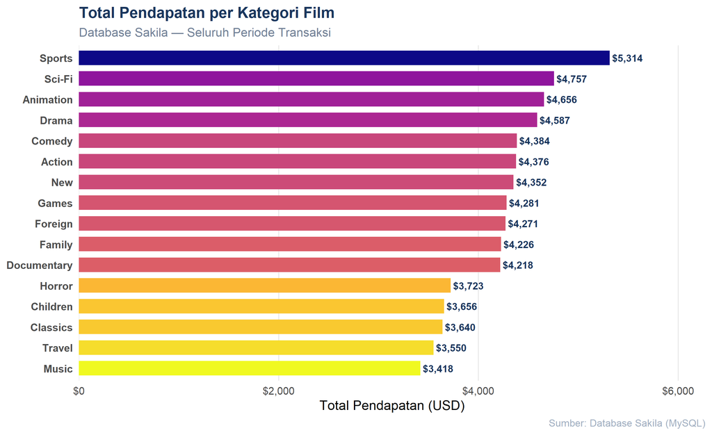

Gambar 1. Total Pendapatan per Kategori Film (diurutkan menurun)

```r
# Urutkan berdasarkan pendapatan
df_kat_sorted <- df_kategori |>
  arrange(total_pendapatan) |>
  mutate(kategori = factor(kategori, levels = kategori))

ggplot(df_kat_sorted, aes(x = total_pendapatan, y = kategori, fill = total_pendapatan)) +
  geom_col(width = 0.7, show.legend = FALSE) +
  geom_text(aes(label = paste0("$", comma(round(total_pendapatan, 0)))),
            hjust = -0.08, size = 3.2, color = "#1a365d", fontface = "bold") +
  scale_fill_viridis_c(option = "plasma", direction = -1) +
  scale_x_continuous(labels = dollar_format(),
                     expand = expansion(mult = c(0, 0.18))) +
  labs(
    title    = "Total Pendapatan per Kategori Film",
    subtitle = "Database Sakila — Seluruh Periode Transaksi",
    x        = "Total Pendapatan (USD)",
    y        = NULL,
    caption  = "Sumber: Database Sakila (MySQL)"
  ) +
  theme_minimal(base_size = 12) +
  theme(
    plot.title    = element_text(face = "bold", size = 14, color = "#1a365d"),
    plot.subtitle = element_text(color = "#718096", size = 11),
    axis.text.y   = element_text(face = "bold"),
    panel.grid.major.y = element_blank(),
    panel.grid.minor   = element_blank(),
    plot.caption  = element_text(color = "#a0aec0", size = 9)
  )
```

### 4.1.2 Interpretasi

Berdasarkan diagram batang horizontal di atas:

Grafik menunjukkan bahwa kategori film **Sports** memiliki total pendapatan tertinggi sebesar **$5.314**, sehingga menjadi kategori paling diminati pelanggan. Sebaliknya, kategori **Music** memiliki pendapatan terendah sebesar **$3.418**. Secara umum, sebagian besar kategori memiliki pendapatan yang relatif stabil di kisaran **$4.000–$5.000**, yang menandakan distribusi pendapatan antar kategori cukup merata.

## 4.2 Analisis 2 — Frekuensi Rental vs. Pendapatan

### 4.2.1 Visualisasi

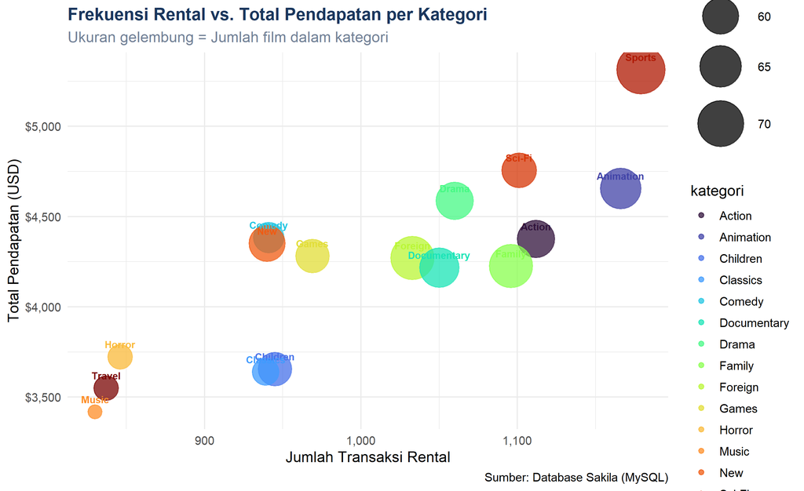

Gambar 2. Perbandingan Frekuensi Rental dan Total Pendapatan per Kategori

```r
ggplot(df_kategori,
       aes(x = jumlah_rental, y = total_pendapatan,
           size = jumlah_film, color = kategori, label = kategori)) +
  geom_point(alpha = 0.75) +
  geom_text(size = 2.8, vjust = -1.2, fontface = "bold", show.legend = FALSE) +
  scale_size_continuous(range = c(5, 18), name = "Jumlah Film") +
  scale_color_viridis_d(option = "turbo") +
  scale_x_continuous(labels = comma) +
  scale_y_continuous(labels = dollar_format()) +
  labs(
    title    = "Frekuensi Rental vs. Total Pendapatan per Kategori",
    subtitle = "Ukuran gelembung = Jumlah film dalam kategori",
    x        = "Jumlah Transaksi Rental",
    y        = "Total Pendapatan (USD)",
    caption  = "Sumber: Database Sakila (MySQL)"
  ) +
  theme_minimal(base_size = 12) +
  theme(
    plot.title    = element_text(face = "bold", size = 14, color = "#1a365d"),
    plot.subtitle = element_text(color = "#718096"),
    legend.position = "right"
  )
```

### 4.2.2 Interpretasi

Diagram gelembung (*bubble chart*) memperlihatkan sebaran hubungan antara frekuensi rental dan pendapatan per kategori:

- Secara visual, kategori dengan jumlah rental lebih tinggi cenderung menghasilkan pendapatan yang lebih besar — namun kecenderungan ini bersifat **deskriptif** dan belum diuji secara statistik.
- **Sports** dan **Animation** menempati posisi unggul baik dari sisi frekuensi maupun pendapatan, menjadikannya kategori prioritas dari perspektif bisnis.
- Ukuran gelembung yang merepresentasikan jumlah film dalam kategori tidak menunjukkan pola yang konsisten terhadap pendapatan — mengindikasikan bahwa **popularitas film lebih menentukan pendapatan daripada banyaknya judul** yang tersedia dalam satu kategori.

## 4.3 Analisis 3 — Tren Rental Bulanan

### 4.3.1 Visualisasi

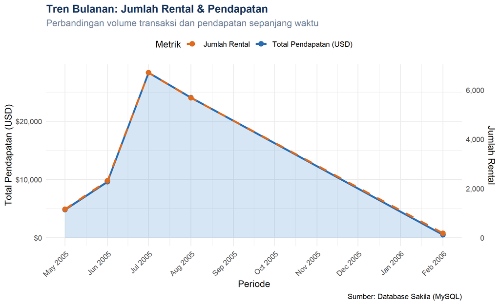

Gambar 3. Tren Jumlah Rental dan Pendapatan Bulanan

```r
# Normalisasi untuk dual-axis
scale_factor <- max(df_bulanan$total_pendapatan) / max(df_bulanan$jumlah_rental)
ggplot(df_bulanan, aes(x = bulan)) +
  geom_area(aes(y = total_pendapatan), fill = "#3182ce", alpha = 0.20) +
  geom_line(aes(y = total_pendapatan, color = "Total Pendapatan (USD)"),
            linewidth = 1.3) +
  geom_line(aes(y = jumlah_rental * scale_factor, color = "Jumlah Rental"),
            linewidth = 1.3, linetype = "dashed") +
  geom_point(aes(y = total_pendapatan, color = "Total Pendapatan (USD)"),
             size = 2.8) +
  geom_point(aes(y = jumlah_rental * scale_factor, color = "Jumlah Rental"),
             size = 2.8) +
  scale_color_manual(values = c("Total Pendapatan (USD)" = "#2b6cb0",
                                 "Jumlah Rental"          = "#dd6b20")) +
  scale_y_continuous(
    name   = "Total Pendapatan (USD)",
    labels = dollar_format(),
    sec.axis = sec_axis(~ . / scale_factor, name = "Jumlah Rental",
                        labels = comma)
  ) +
  scale_x_date(date_labels = "%b %Y", date_breaks = "1 month") +
  labs(
    title    = "Tren Bulanan: Jumlah Rental & Pendapatan",
    subtitle = "Perbandingan volume transaksi dan pendapatan sepanjang waktu",
    x        = "Periode",
    color    = "Metrik",
    caption  = "Sumber: Database Sakila (MySQL)"
  ) +
  theme_minimal(base_size = 12) +
  theme(
    plot.title    = element_text(face = "bold", size = 14, color = "#1a365d"),
    plot.subtitle = element_text(color = "#718096"),
    axis.text.x   = element_text(angle = 45, hjust = 1),
    legend.position = "top"
  )
```

## 4.4 Analisis 4 — Hubungan Durasi Film dengan Pendapatan

### 4.4.1 Landasan Teori & Persamaan Matematis

Untuk mengukur kekuatan hubungan linear antara durasi film ($X$) dan total pendapatan ($Y$), digunakan **Koefisien Korelasi Pearson**:

$$r = \frac{\sum_{i=1}^{n}(X_i - \bar{X})(Y_i - \bar{Y})}
{\sqrt{\sum_{i=1}^{n}(X_i - \bar{X})^2 \cdot \sum_{i=1}^{n}(Y_i
- \bar{Y})^2}}$$

di mana $r \in [-1, 1]$. Nilai $r$ mendekati 1 berarti korelasi positif kuat, mendekati -1 berarti korelasi negatif kuat, dan mendekati 0 berarti tidak ada korelasi linear.

Selanjutnya dilakukan **Regresi Linear Sederhana** dengan model:

$$\hat{Y}_i = \beta_0 + \beta_1 X_i + \varepsilon_i, \quad \varepsilon_i
\sim \mathcal{N}(0, \sigma^2)$$

Estimasi koefisien menggunakan metode *Ordinary Least Squares* (OLS):

$$\hat{\beta}_1 = \frac{\sum_{i=1}^{n}(X_i - \bar{X})(Y_i -
\bar{Y})}{\sum_{i=1}^{n}(X_i - \bar{X})^2}, \qquad
\hat{\beta}_0 = \bar{Y} - \hat{\beta}_1\bar{X}$$

Koefisien determinasi $R^2$ mengukur proporsi variansi $Y$ yang dijelaskan model:

$$R^2 = 1 - \frac{\text{SS}_{\text{res}}}{\text{SS}_{\text{tot}}} = 1 -
\frac{\sum(Y_i - \hat{Y}_i)^2}{\sum(Y_i - \bar{Y})^2}$$

### 4.4.2 Uji Korelasi

```r
# Korelasi Pearson
cor_result <- cor.test(df_durasi$durasi_menit, df_durasi$total_pendapatan,
                       method = "pearson")

cat("=== Hasil Uji Korelasi Pearson ===\n")
```

```
## === Hasil Uji Korelasi Pearson ===
```

```r
cat("r         :", round(cor_result$estimate, 4), "\n")
```

```
## r         : -0.004
```

```r
cat("t-statistik:", round(cor_result$statistic, 4), "\n")
```

```
## t-statistik: -0.125
```

```r
cat("p-value   :", format(cor_result$p.value, scientific = TRUE), "\n")
```

```
## p-value   : 9.005671e-01
```

```r
cat("95% CI    : [", round(cor_result$conf.int[1], 4), ",",
                     round(cor_result$conf.int[2], 4), "]\n")
```

```
## 95% CI    : [ -0.0674 , 0.0593 ]
```

### 4.4.3 Regresi Linear

```r
# Model regresi linear sederhana
model_lm <- lm(total_pendapatan ~ durasi_menit, data = df_durasi)
summary_lm <- summary(model_lm)

# Tampilkan koefisien
kable(tidy(model_lm),
      digits  = 4,
      caption = "Tabel 3. Hasil Estimasi Regresi Linear (Pendapatan ~ Durasi Film)",
      col.names = c("Term", "Estimasi", "Std. Error", "t-Statistik", "p-value")) |>
  kable_styling(bootstrap_options = c("striped","hover"), full_width = FALSE,
                position = "center")
```

Tabel 3. Hasil Estimasi Regresi Linear (Pendapatan ~ Durasi Film)

| Term | Estimasi | Std. Error | t-Statistik | p-value |
| --- | --- | --- | --- | --- |
| (Intercept) | 70.8495 | 4.1355 | 17.1322 | 0.0000 |
| durasi_menit | -0.0042 | 0.0338 | -0.1250 | 0.9006 |

```r
cat("\nR-squared :", round(summary_lm$r.squared, 4))
```

```
##
## R-squared : 0
```

```r
cat("\nAdj. R²   :", round(summary_lm$adj.r.squared, 4))
```

```
##
## Adj. R²   : -0.001
```

### 4.4.4 Visualisasi Regresi

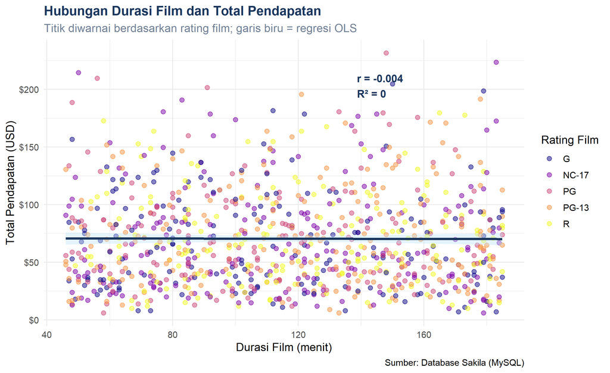

Gambar 4. Scatter Plot Durasi Film vs. Total Pendapatan dengan Garis Regresi

```r
ggplot(df_durasi, aes(x = durasi_menit, y = total_pendapatan)) +
  geom_point(aes(color = rating), alpha = 0.5, size = 2) +
  geom_smooth(method = "lm", se = TRUE, color = "#1a365d",
              fill = "#bee3f8", linewidth = 1.2) +
  scale_color_viridis_d(option = "plasma", name = "Rating Film") +
  scale_y_continuous(labels = dollar_format()) +
  annotate("text",
           x = max(df_durasi$durasi_menit) * 0.75,
           y = max(df_durasi$total_pendapatan) * 0.92,
           label = paste0("r = ", round(cor_result$estimate, 3),
                          "\nR² = ", round(summary_lm$r.squared, 3)),
           size = 4, color = "#1a365d", fontface = "bold",
           hjust = 0, vjust = 1,
           box.padding = unit(0.4, "lines")) +
  labs(
    title    = "Hubungan Durasi Film dan Total Pendapatan",
    subtitle = "Titik diwarnai berdasarkan rating film; garis biru = regresi OLS",
    x        = "Durasi Film (menit)",
    y        = "Total Pendapatan (USD)",
    caption  = "Sumber: Database Sakila (MySQL)"
  ) +
  theme_minimal(base_size = 12) +
  theme(
    plot.title    = element_text(face = "bold", size = 14, color = "#1a365d"),
    plot.subtitle = element_text(color = "#718096"),
    legend.position = "right"
  )
```

### 4.4.5 Interpretasi

**Hasil Korelasi & Regresi:**

- Unit analisis adalah **per film**, dengan nilai pendapatan merupakan agregasi seluruh transaksi rental tiap judul.
- Nilai $r \approx$ -0.004 dan $R^2 \approx$ 0 menunjukkan bahwa durasi film **hampir tidak berkorelasi** dengan pendapatan yang dihasilkan.
- Durasi film hanya menjelaskan 0% variasi pendapatan — faktor lain seperti popularitas film, harga rental, dan ketersediaan stok jauh lebih menentukan.

# 5 Kesimpulan

Berdasarkan seluruh analisis yang telah dilakukan terhadap database Sakila, dapat ditarik kesimpulan sebagai berikut:

[output not shown]

**📌 Rekomendasi Strategis:**

1. Tingkatkan koleksi film kategori Sports, Sci-Fi, dan Animation.
2. Lakukan kampanye marketing menjelang periode puncak (pertengahan tahun).
3. Kaji ulang harga rental untuk kategori dengan permintaan tinggi.
4. Lakukan analisis segmentasi pelanggan sebagai langkah lanjutan.